# Intro

This dashboard covers the course materials for the course [**USS24: Statistical programming with R**](https://www.utrechtsummerschool.nl/courses/social-sciences/data-science-statistical-programming-with-r).  
We usually adapt the course as we go, so we suggest to access the materials online when we consider them.

Instructors:

- [Laurence Frank](https://www.uu.nl/staff/lefrank) (course leader)
- [Maarten Cruyff](https://www.uu.nl/staff/mcruyff)
- [Mahdi Shafiee Kamalabad](https://www.uu.nl/staff/MShafieeKamalabad/)
- [David Goretzko](https://www.uu.nl/staff/DGoretzko)

Study load: 1.5 ECTS  
Location of Start: [Victor J. Koningsberger Building, room Pangea](https://www.uu.nl/en/victor-j-koningsberger-building)

# Quick Overview

### Outline

R is rapidly becoming the standard platform for data manipulation, visualization and analysis and has a number of advantages over other statistical software packages. A wide community of users contribute to R, resulting in an enormous coverage of statistical procedures, including many that are not available in any other statistical program. Furthermore, it is highly flexible for programming and scripting purposes, for example when manipulating data or creating professional plots. However, R lacks standard GUI menus, as in SPSS for example, from which to choose what statistical test to perform or which graph to create. As a consequence, R is more challenging to master. Therefore, this course offers an elaborate introduction into statistical programming in R. Students learn to operate R, make plots, fit, assess and interpret a variety of basic statistical models and do advanced statistical programming and data manipulation. The topics in this course include regression models for linear, dichotomous, ordinal and multivariate data, statistical inference, statistical learning, bootstrapping and Monte Carlo simulation techniques.

The course deals with the following topics:

1. An introduction to the R environment.
2. Basic to advanced programming skills: data generation, manipulation, pipelines, summaries and plotting.
3. Fitting statistical models: estimation, prediction and testing.
4. Drawing statistical inference from data.
5. Basic statistical learning techniques.
6. Bootstrapping and Monte Carlo simulation.

The course starts at a very basic level and builds up gradually. At the end of the week, participants will master advanced programming skills with R. No previous experience with R is required.

Prerequisites: Participants are requested to bring their own laptop for lab meetings.

### Certificate

Participants will receive a certificate at the end of the course.

### Daily schedule

| When? |  | What? |
| --- | --- | --- |
| 09.00 | 09.30 | Lecture |
| 09:30 | 10.15 | Practical |
| 10.15 | 10.45 | Discussion |
| 10.45 | 11:00 | **break** |
| 11.00 | 11.45 | Lecture |
| 11:45 | 13:00 | [Lunch](https://goo.gl/maps/GuxZQUCvtQixgzVE8) |
| 13:00 | 14.00 | Practical |
| 14:00 | 14.30 | Discussion |
| 14:30 | 14:45 | **break** |
| 14:45 | 15:45 | Lecture |
| 15:45 | 16.30 | Practical |
| 16:30 | 17:00 | Discussion |

### Lecture Hall locations

| When? | Where |
| --- | --- |
| Monday | [Viktor J. Koningsberger building, Room Pangea](https://goo.gl/maps/ufn6aXVL9K48Gn7S6) |
| Tuesday | [Viktor J. Koningsberger building, Room Pangea](https://goo.gl/maps/ufn6aXVL9K48Gn7S6) |
| Wednesday | [Viktor J. Koningsberger building, Room Pangea](https://goo.gl/maps/ufn6aXVL9K48Gn7S6) |
| Thursday | [Viktor J. Koningsberger building, Room Pangea](https://goo.gl/maps/jG6Vzv5ugfCXvR8x8) |
| Friday | [Viktor J. Koningsberger building, Room Pangea](https://goo.gl/maps/ufn6aXVL9K48Gn7S6) |

# How to prepare

### Preparing your machine for the course

Dear all,

This summer you will participate in the [**USS24: Statistical programming with R**](https://www.utrechtsummerschool.nl/courses/social-sciences/data-science-statistical-programming-with-r) course in Utrecht, the Netherlands. To realize a steeper learning curve, we will use some functionality that is not part of the base installation for `R`. The below steps guide you through installing both `R` as well as the necessary additions.

We look forward to see you all in Utrecht,

*The Statistical Programming with R Team*

### **System requirements**

Bring a laptop computer to the course and make sure that you have full write access and administrator rights to the machine. We will explore programming and compiling in this course. This means that you need full access to your machine. Some corporate laptops come with limited access for their users, we therefore advice you to bring a personal laptop computer, if you have one.

### **1. Install the latest version of `R`**

`R` can be obtained [here](https://cran.r-project.org). We won’t use `R` directly in the course, but rather call `R` through `RStudio`. Therefore it needs to be installed.

### **2. Install the latest `RStudio` Desktop**

Rstudio is an Integrated Development Environment (IDE). It can be obtained as stand-alone software [here](https://www.rstudio.com/products/rstudio/download/#download). The free and open source `RStudio Desktop` version is sufficient.

### **3. Start RStudio and install the following packages.**

Execute the following lines of code in the console window:

```r
install.packages(c("ggplot2", "tidyverse", "magrittr", "knitr", "rmarkdown",
                   "plotly", "ggplot2", "shiny", "devtools", "boot", "class",
                   "car", "MASS", "ggplot2movies", "ISLR", "DAAG", "mice",
                   "purrr", "furrr", "future"), dependencies = TRUE)
```

If you are not sure where to execute code, use the following figure to identify the console - ignore the outdated version in the example:

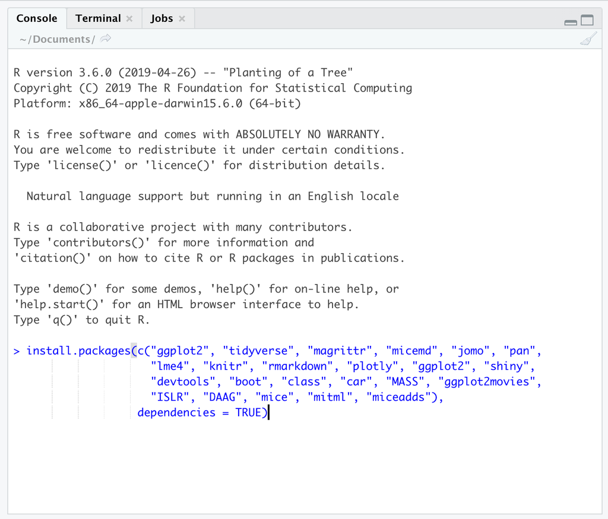

Just copy and paste the installation command and press the return key. When asked

```r
Do you want to install from sources the package which needs
compilation? (Yes/no/cancel)
```

type `Yes` in the console and press the return key.

### **What if the steps to the left do not work for me?**

If all fails and you have insufficient rights to your machine, the following web-based service will offer a solution.

1. You will receive an account to Utrecht University’s [MyWorkPlace](https://myworkplace.uu.nl/). You would have access to `R` and `RStudio` there. You may need to install packages for new sessions during the course.
2. Open a free account on rstudio.cloud. You can run your own cloud-based `RStudio` environment there.

Naturally, you will need internet access for these services to be accessed. Wireless internet access will be available at the course location.

# Monday

### Monday’s materials

We adapt the course as we go. To ensure that you work with the latest iteration of the course materials, we advice all course participants to access the materials online.

- Part A: Introduction
  - Lecture A slides
  - Lecture A Handout
  - Practical A: Exercises
  - Practical A: Template
  - Practical A: Solutions
  - [Install R on UU laptop](https://gist.github.com/vankesteren/f2e198aa5ab4f6262b21a3d13bbea0b5)
- Part B: How is `R` organized?
  - Lecture B slides
  - Lecture B Handout
  - Practical B: Exercises
  - Practical B: Template
  - Pactical B: Solutions
  - `boys.RData`
- Part C: `R` Functionality
  - Lecture C slides
  - Lecture C Handout
  - Practical C: Exercises
  - Practical C: Template
  - Practical C: Solutions

All lectures are in `html` format and have two versions: the slides and the handout version. Practical template files are `R Markdown` files with the exercises of the practicals. Fill in the the code (the answers) in these files. Practical solutions files give the answers to the exercises of the practicals.

### Useful references

- [An introduction in R Markdown](https://rmarkdown.rstudio.com/index.html)
- [R Markdown: The Definitive Guide](https://bookdown.org/yihui/rmarkdown/)
- [The tidyverse style guide](https://style.tidyverse.org)
- [The Google R style guide](https://google.github.io/styleguide/Rguide.xml)

The above links are useful references that connect to today’s materials.

### About `rmarkdown`

[video not shown]

[What is R Markdown?](https://vimeo.com/178485416) from [RStudio, Inc.](https://vimeo.com/rstudioinc) on [Vimeo](https://vimeo.com).

See also this `rmarkdown` cheat sheet.

# Tuesday

### Tuesday’s materials

We adapt the course as we go. To ensure that you work with the latest iteration of the course materials, we advice all course participants to access the materials online.

- Part D: Generating Data
  - Lecture D
  - Practical D: Template
  - Practical D: Solutions
- Part E: Custom functions
  - Lecture E
  - Practical E: Template
  - Practical E: Solutions
- Part F: Pipes
  - Lecture F
  - Practical F: Template
  - Practical F: Solutions

All lectures are in `html` format and have two versions: the slides and the handout version. Practical template files are `R Markdown` files with the exercises of the practicals. Fill in the the code (the answers) in these files. Practical solutions files give the answers to the exercises of the practicals.

### Useful References

- [`magrittr`](https://magrittr.tidyverse.org)
- [`R` for Data Science](http://r4ds.had.co.nz)
- [Chapter 18 on pipes](http://r4ds.had.co.nz/pipes.html)

The above links are useful references that connect to today’s materials.

# Wednesday

### Wednesday’s materials

We adapt the course as we go. To ensure that you work with the latest iteration of the course materials, we advice all course participants to access the materials online.

- Part G: Statistical Inference
  - Lecture G
  - Practical G: Template
  - Practical G: Solutions
- Part H: Statistical models
  - Lecture H
  - Practical H: Template
  - Practical H: Solutions
- Part I: Data visualization
  - Lecture I
  - Practical I: Template
  - Practical I: Solutions

All lectures are in `html` format and have two versions: the slides and the handout version. Practical template files are `R Markdown` files with the exercises of the practicals. Fill in the the code (the answers) in these files. Practical solutions files give the answers to the exercises of the practicals.

### Useful links

- [The `ggplot2` reference page](https://ggplot2.tidyverse.org/reference/)
- [The R Graph Gallery: an overview of plots you can make with R code provided](https://r-graph-gallery.com/)
- [A great reference on contrasts with linear modeling](https://rstudio-pubs-static.s3.amazonaws.com/65059_586f394d8eb84f84b1baaf56ffb6b47f.html)
- These papers are a nice reference for editors:
  - [A comment in Nature from 800+ signatories](https://www.nature.com/articles/d41586-019-00857-9)
  - [Naomi Altman and Martin Krzywinski in Nature Methods](https://www.nature.com/articles/nmeth.4120)
  - [Statement by the Americal Statistical Association](https://www.tandfonline.com/doi/full/10.1080/00031305.2016.1154108)

### Releveling

```r
library(mice)
library(magrittr)
boys %$% lm(age ~ reg) %>% coef()
```

```
(Intercept)     regeast     regwest    regsouth     regcity
  11.898420   -2.656786   -2.900792   -3.307388   -3.626625
```

```r
boys$reg <- relevel(boys$reg, ref = "south")
boys %$% lm(age ~ reg) %>% coef()
```

```
(Intercept)    regnorth     regeast     regwest     regcity
  8.5910314   3.3073883   0.6506021   0.4065962  -0.3192369
```

# Thursday

### Thursday’s materials

We adapt the course as we go. To ensure that you work with the latest iteration of the course materials, we advice all course participants to access the materials online.

- Part J: Model estimation
  - Practical J: Template
  - Practical J: Solutions
- Part K: Prediction
  - Lecture K
  - Practical K: Template
  - Practical K: Solutions
- Part L: Generalized Linear Models
  - Lecture L
  - Practical L: Template
  - Practical L: Solutions

All lectures are in `html` format and have two versions: the slides and the handout version. Practical template files are `R Markdown` files with the exercises of the practicals. Fill in the the code (the answers) in these files. Practical solutions files give the answers to the exercises of the practicals.

### Useful links

- [The R Graph Gallery: an overview of plots you can make in R (with code provided)](https://r-graph-gallery.com/)
- [Make nice tables in R Markdown with `gtsummary`](https://www.danieldsjoberg.com/gtsummary/index.html)
- Reproducible summary tables with `gtsummary`
- [`gtsummary` cheat sheet](https://github.com/rstudio/cheatsheets/blob/main/gtsummary.pdf)

# Friday

### Friday’s materials

We adapt the course as we go. To ensure that you work with the latest iteration of the course materials, we advice all course participants to access the materials online.

- Part M: Bootstrap
  - Lecture
  - Practical: Solutions
  - Practical: Markdown file
- Part N: Unsupervised learning
  - Lecture
  - Practical: Solutions
  - Practical: Markdown file
- Part O: Monte Carlo simulation
  - Lecture O
  - Practical O
  - Impractical O
- Shiny apps
  - Lecture Shiny apps
  - Practical Shiny Part 1
  - Practical Shiny Part 2
  - Solutions ui.R file Practical Part 2
  - Solutions server.R file Practical Part 2

All lectures are in `html` format and have two versions: the slides and the handout version. Practical template files are `R Markdown` files with the exercises of the practicals. Fill in the the code (the answers) in these files. Practical solutions files give the answers to the exercises of the practicals.

### Useful links

- [Online book: Mastering Shiny by Hadley Wickham](https://mastering-shiny.org/index.html)
- [Shiny apps in eduction at Utrecht University](https://utrechtuniversity.github.io/ShinyEducation/apps/)

# To continue

### What to do after the course

- [R for Data Science](https://r4ds.had.co.nz): a wonderful book that details a usefull toolset for current and aspiring data scientists.
- [Introduction to Statistical Learning](https://www.statlearning.com): an introductory book on statistical learning, with applications in R.
- [Data Analysis and Graphics Using R](https://maths-people.anu.edu.au/~johnm/r-book/daagur3.html): a detailed book that covers a lot about categorical data analysis and fitting `glm`s in `R`.

The above references are (currently) available for free in these links. I deem them very useful and I would highly recommend them.